# Homework2

# Problem 8

**Regression: Marketing data.The data setage_stats315B.csvwas already used in Homework 1. Reviewage_stats315B.txt for the information about order of attributes etc.(a) Fit a gbm model for predicting age from the other demographic attributes and compare the accuracy with the accuracy of your best single tree from Homework 1.**

## 8.0 Data Import

```r
age <- read_excel("age_stats315B.xlsx")


age <- age %>%
  mutate_if(is.character, as.numeric) %>% # Changing all values to numeric
  janitor::clean_names()

age
```

```
## # A tibble: 8,710 x 14
##      age occup type_home   sex mar_stat   edu income live_ba dual_inc persons
##    <dbl> <dbl>     <dbl> <dbl>    <dbl> <dbl>  <dbl>   <dbl>    <dbl>   <dbl>
##  1     5     5         1     2        1     4      9       5        3       3
##  2     5     5         1     1        1     5      9       5        3       5
##  3     3     1         3     2        1     5      9       5        2       3
##  4     1     6         1     2        5     2      1       5        1       4
##  5     1     6         1     2        5     2      1       3        1       4
##  6     6     8         1     1        1     4      8       5        3       2
##  7     2     9         3     1        5     3      1       4        1       3
##  8     3     3         3     1        3     4      6       5        1       1
##  9     6     8         3     1        1     3      2       5        3       3
## 10     7     8         3     1        1     4      4       4        3       2
## # … with 8,700 more rows, and 4 more variables: under18 <dbl>,
## #   house_stat <dbl>, ethnic <dbl>, lang <dbl>
```

```r
# Chanmging categorical varaibles to factor
age <- age %>%
  mutate_at(vars(occup,
                  type_home,
                  lang,
                  ethnic,
                  edu,
                  sex,
                  mar_stat,
                 dual_inc,
                 house_stat
                 ),
             funs(factor))
```

## 8.1 Data Pre-Processing

```r
# Initial Split of the data

age_rf <- initial_split(age)

# Data split for random forest modelling
age_rf_train <- training(age_rf)
age_rf_testing <- testing(age_rf)

#Specifying the variable to be predicted by the model
age_rec <- recipe(age ~., data = age_rf_train)

# Adding pre-processing steps to the recipe

age_prc <- age_rec %>% # Providing the role to the outcome variable
  step_naomit(all_predictors()) %>% # In the previous Homework1 I remember missing values in the data set, I am removing those here because Random Forest does not handle NAs
  step_dummy(all_predictors(), -all_numeric()) %>% # Converting the factor variables into dummy varibles. Step required before centering and scaling.
  step_normalize(all_predictors()) # Data needs to be normalized for the Random Forest Model.


age_rf_rec <- prep(age_prc, age_rf_train)
age_rf_juic_train <- bake(age_rf_rec, age_rf_train)
age_rf_juic_test  <- bake(age_rf_rec, new_data = age_rf_testing)
```

**(a) Fit a gbm model for predicting age form the other demographic attributes and compare the accuracy with the accuracy of your best single tree from Homework 1.**

```r
age.gbm.model <- gbm(age~.,
                     data = age_rf_juic_train,
                     interaction.depth = 5,
                     shrinkage = 0.04,
                     n.trees = 1000,
                     cv.folds = 10)
```

```
## Distribution not specified, assuming gaussian ...
```

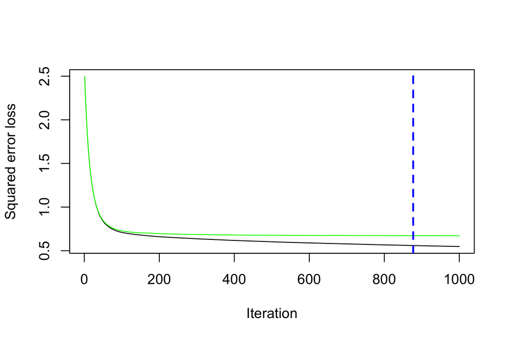

```
## [1] 877
```

```r
gbm.perf(age.gbm.model, method = 'cv') # Cross-Validation with 5-folds.
```

## 8.3 Predicting on the test dataset

```r
# Making predicitons
gbm.pred.df <- predict(age.gbm.model, age_rf_juic_test) %>%
  as.data.frame() %>%
  rename('gbm.predictions' = '.')
```

```
## Using 877 trees...
```

```r
# First 6 predicitons of the gbm model
head(gbm.pred.df)
```

```
##   gbm.predictions
## 1        4.540960
## 2        3.673351
## 3        3.953731
## 4        4.207472
## 5        3.769720
## 6        1.053002
```

## 8.4 Evaluting on the testing data set

```r
gbm.accuracy <- sum(round(gbm.pred.df))

df.true.pred <- age_rf_juic_test %>% select(age) %>%
  bind_cols(gbm.pred.df) %>%
  mutate(gbm.predictions = round(gbm.predictions))

gbm.model.acc <- (sum(df.true.pred$gbm.predictions == df.true.pred$age)) /nrow(df.true.pred)
scales::percent(round(gbm.model.acc, 2))
```

```
## [1] "52%"
```

```r
gbm.model.acc
```

```
## [1] 0.5205399
```

## 8.5 Comparing results to previous Decision Tree - Homework 1

```r
dec.tree <- rpart(age~., data = age_rf_juic_train)
dec.pred <- predict(dec.tree, age_rf_juic_test) %>%
  as.data.frame() %>%
  rename('dec.predictions' = '.')

df.true.pre.tree <- age_rf_juic_test %>%
  select(age) %>%
  bind_cols(dec.pred) %>%
  mutate(dec.predictions = round(dec.predictions))

tree.model.acc <- (sum(df.true.pre.tree$dec.predictions == df.true.pre.tree$age)) /nrow(df.true.pre.tree)
scales::percent(round(tree.model.acc,2))
```

```
## [1] "47%"
```

Let’s now evaluate the importance of the variable in the model.

## 8.6 Most Important Features in the GBM Model

```r
importance <- summary(age.gbm.model) %>%
  as.data.frame()

importance %>%
  mutate(var = fct_reorder(var, rel.inf)) %>%
  head(10) %>%
  ggplot(aes(var, rel.inf)) +
  geom_point() +
  coord_flip() +
  labs(title = 'Top 10 Important Variables in the Model',
       y = "Relative Importance",
       x = 'Variables')
```

[output not shown]

# Problem 9

## TBC!

**Multiclass classification: marketing data.The data set occup_stats315B.csv comes from the same marketing database used in Homework 1. The description of the attributes can be found in occup_stats315B.txt. The goal in this problem is to fit a gbm model to predict the type of occupation from the 13 other demographic variables.**

**(a) Report the test set misclassification error for gbm on the data set, and also the misclassification error for each class.**

**(b) Identify the most important variables.**

## Data Import 9.0

```r
library(readr)
occup_stats <- read_csv("occup_stats315B.csv",
                        col_names = FALSE)

occu_header <- c('occupation', 'home_type', 'sex', 'marital', 'age', 'education', 'annual_income', 'living_bay_area', 'dual_income', 'ppl_household', 'ppl_under18',
                 'household_status', 'ethnicity', 'lang')

colnames(occup_stats) <- occu_header

occup_stats <- occup_stats %>%
  mutate_at(vars(occupation,
                 home_type,
                 ethnicity,
                 education,
                 sex,
                 marital,
                 dual_income,
                 household_status,
                 lang
  ),
  funs(factor))
```

## Data Split 9.1

```r
library(skimr)
skim(occup_stats)
```

Data summary

| Name | occup_stats |
| --- | --- |
| Number of rows | 8857 |
| Number of columns | 14 |
| _______________________ |  |
| Column type frequency: |  |
| factor | 9 |
| numeric | 5 |
| ________________________ |  |
| Group variables | None |

**Variable type: factor**

| skim_variable | n_missing | complete_rate | ordered | n_unique | top_counts |
| --- | --- | --- | --- | --- | --- |
| occupation | 0 | 1.00 | FALSE | 9 | 1: 2798, 6: 1475, 4: 1049, 2: 786 |
| home_type | 0 | 1.00 | FALSE | 5 | 1: 5229, 3: 2408, 2: 661, 5: 399 |
| sex | 0 | 1.00 | FALSE | 2 | 2: 4889, 1: 3968 |
| marital | 146 | 0.98 | FALSE | 5 | 5: 3610, 1: 3300, 3: 837, 2: 658 |
| education | 80 | 0.99 | FALSE | 6 | 4: 3000, 3: 2012, 5: 1498, 2: 1029 |
| dual_income | 0 | 1.00 | FALSE | 3 | 1: 5345, 2: 2171, 3: 1341 |
| household_status | 190 | 0.98 | FALSE | 3 | 2: 3588, 1: 3259, 3: 1820 |
| ethnicity | 59 | 0.99 | FALSE | 8 | 7: 5773, 5: 1193, 3: 868, 2: 469 |
| lang | 352 | 0.96 | FALSE | 3 | 1: 7687, 2: 562, 3: 256 |

**Variable type: numeric**

| skim_variable | n_missing | complete_rate | mean | sd | p0 | p25 | p50 | p75 | p100 | hist |
| --- | --- | --- | --- | --- | --- | --- | --- | --- | --- | --- |
| age | 0 | 1.00 | 3.42 | 1.65 | 1 | 2 | 3 | 4 | 7 | ▇▆▅▂▃ |
| annual_income | 349 | 0.96 | 4.94 | 2.77 | 1 | 2 | 5 | 7 | 9 | ▇▅▂▇▇ |
| living_bay_area | 906 | 0.90 | 4.20 | 1.23 | 1 | 4 | 5 | 5 | 5 | ▁▂▁▂▇ |
| ppl_household | 318 | 0.96 | 2.88 | 1.55 | 1 | 2 | 3 | 4 | 9 | ▇▆▁▁▁ |
| ppl_under18 | 0 | 1.00 | 0.68 | 1.09 | 0 | 0 | 0 | 1 | 9 | ▇▂▁▁▁ |

```r
# I discovered some classs imbalance in the gender so I am stratifying for it in the initial training-test split
occup_stats %>%
  count(sex)
```

```
## # A tibble: 2 x 2
##   sex       n
##   <fct> <int>
## 1 1      3968
## 2 2      4889
```

```r
initial_split_occu <- initial_split(occup_stats, strata = sex) # Stratify on the gender class imbalance.
occup_train <- training(initial_split_occu)
occup_test <- testing(initial_split_occu)
```

# Data Pre-Processing

I think there is a lot to improve from the HW1 with gbm model and will make it better with some data pre-processing to normalize and scale the data before fitting the gbm model.

Will also upsample the data for the outcome variable.

```r
library(tidymodels)


occup_rec <- recipe(occupation~ .,
                    data = occup_train) %>%
  step_upsample(occupation) %>%  # Upsampling the outcome variable.
  step_knnimpute(all_predictors()) %>% # There are missing variables, imputing them using knn
  step_dummy(all_nominal(), -all_outcomes()) %>%
  step_normalize(all_predictors(), -all_outcomes()) %>%
  step_scale(all_predictors()) %>%
  step_zv(all_predictors()) %>%
  prep(retain = T)

occup_rec
```

```
## Data Recipe
##
## Inputs:
##
##       role #variables
##    outcome          1
##  predictor         13
##
## Training data contained 6643 data points and 1465 incomplete rows.
##
## Operations:
##
## Up-sampling based on occupation [trained]
## K-nearest neighbor imputation for sex, marital, age, education, ... [trained]
## Dummy variables from home_type, sex, marital, education, ... [trained]
## Centering and scaling for age, annual_income, ... [trained]
## Scaling for age, annual_income, ... [trained]
## Zero variance filter removed no terms [trained]
```

```r
train_proc <- bake(occup_rec, new_data = occup_train)
test_proc <- bake(occup_rec, new_data = occup_test)


# Chech the head of the new pre-processed data
head(train_proc, 10)
```

```
## # A tibble: 10 x 33
##       age annual_income dual_income_X2 dual_income_X3 education_X2 education_X3
##     <dbl>         <dbl>          <dbl>          <dbl>        <dbl>        <dbl>
##  1  0.878         1.64          -0.500          2.08        -0.373       -0.637
##  2  0.878         1.64          -0.500          2.08        -0.373       -0.637
##  3 -0.265         1.64           2.00          -0.481       -0.373       -0.637
##  4 -1.41         -1.31          -0.500         -0.481        2.68        -0.637
##  5  1.45          1.27          -0.500          2.08        -0.373       -0.637
##  6 -0.836        -1.31          -0.500         -0.481       -0.373        1.57
##  7  1.45         -0.945         -0.500          2.08        -0.373        1.57
##  8  2.02         -0.207         -0.500          2.08        -0.373       -0.637
##  9 -0.836        -1.31          -0.500         -0.481       -0.373       -0.637
## 10 -0.836        -0.207         -0.500         -0.481       -0.373        1.57
## # … with 27 more variables: education_X4 <dbl>, education_X5 <dbl>,
## #   education_X6 <dbl>, ethnicity_X2 <dbl>, ethnicity_X3 <dbl>,
## #   ethnicity_X4 <dbl>, ethnicity_X5 <dbl>, ethnicity_X6 <dbl>,
## #   ethnicity_X7 <dbl>, ethnicity_X8 <dbl>, home_type_X2 <dbl>,
## #   home_type_X3 <dbl>, home_type_X4 <dbl>, home_type_X5 <dbl>,
## #   household_status_X2 <dbl>, household_status_X3 <dbl>, lang_X2 <dbl>,
## #   lang_X3 <dbl>, living_bay_area <dbl>, marital_X2 <dbl>, marital_X3 <dbl>,
## #   marital_X4 <dbl>, marital_X5 <dbl>, occupation <fct>, ppl_household <dbl>,
## #   ppl_under18 <dbl>, sex_X2 <dbl>
```

# Model Training

```r
gbm.occupation.model <- gbm(occupation~.,
                            data = train_proc,
                            interaction.depth = 5,
                            shrinkage = 0.05,
                            n.trees = 400,
                            cv.folds = 3,
                            distribution = 'multinomial',
                            verbose = T)
best_iteration_occup <- gbm.perf(gbm.occupation.model, method = 'cv')
```

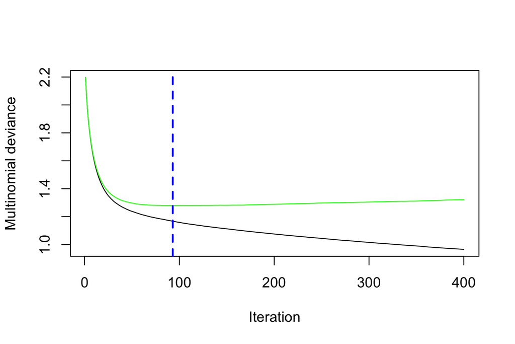

```r
best_iteration_occup
```

```
## [1] 93
```

```r
# Predicting on the testing set
gbm.occup.pred <- predict(gbm.occupation.model,
                          test_proc,
                          n.trees = best_iteration_occup,
                          type = 'response') %>%
  as.data.frame() %>%
  mutate(pred = round(as.integer(names(.)[apply(., 1, which.max)])),
         pred = as.factor(pred)) %>%
  bind_cols(test_proc) %>%
  select(pred, occupation)
```

**(a) Report the test set misclassification error for gbm on the data set, and also the misclassification error for each class.**

Here we can see that the lowest accuacy on the test set, was achieved for the class 9 and 2. (Unemployed and Sales Worker). On the other hand, the classes that achieved the best accuracy were: 8 (Retired) and 5 (Homemaker).

```r
confusion_matrix.occup <- table(gbm.occup.pred)


missclassification.each.class <- diag(prop.table(confusion_matrix.occup,1))
missclassification.each.class
```

```
##         1         2         3         4         5         6         7         8
## 0.6290323 0.2800000 0.3259669 0.3424658 0.7000000 0.6107660 0.6486486 0.6782178
##         9
## 0.1764706
```

**Overall Misscalsification**

```r
missclasifiation.error <- gbm.occup.pred %>%
  mutate(correct = case_when(pred == occupation ~ 'correct', TRUE ~ 'incorrect')) %>%
  count(correct) %>%
  mutate(sum = sum(n),
         error = n/sum) %>%
  select(error) %>%
  tail(1)

missclasifiation.error
```

```
## # A tibble: 1 x 1
##   error
##   <dbl>
## 1 0.434
```

**(b) Identify the most important variables.**

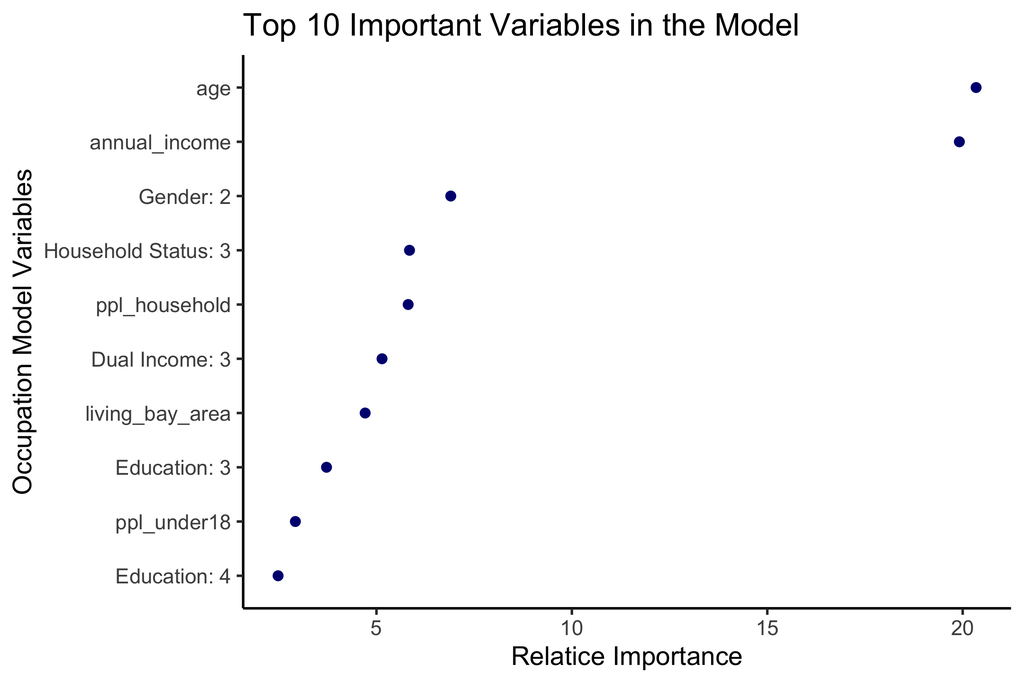

```r
importance.occup %>%
  mutate(var = str_replace(var,'household_status_X', 'Household Status: '),
         var = str_replace(var,'sex_X', 'Gender: '),
         var = str_replace(var,'dual_income_X', 'Dual Income: '),
         var = str_replace(var,'education_X', 'Education: '),
         var = fct_reorder(var, rel.inf)) %>%
  top_n(10) %>%
  ggplot(aes(rel.inf, var)) +
  geom_point(color = 'navy blue') +
  labs(title = 'Top 10 Important Variables in the Model',
       y = "Occupation Model Variables",
       x = 'Relatice Importance')
```

The most important variables to predict the ocupation of a worker are Age, Annual Income, Household Status: Live with Parent/Family (I guess these are students and retired people, open to further investigation), Gender: Female.